# Metode kineziološkega raziskovanja II

**Skripta je bila napisana s pomočjo generativne umetne inteligence (OpenAI; Codex Različica 26.1029.61003)*

## Povzetek

Podatkovna zbirka vsebuje podatke pridobljene iz 10 različnih indijskih bolnišnic, kjer so zbrali podatke 541 žensk. Napovedna spremenljivka, `PCOS (Y/N)` je binarna in daje informacijo ali je bila pacientka diagnosticirana s sindromom policističnih jajčnikov (PCOS). Poleg napovedne spremenljivke je bilo zbranih še 41 drugih spremenljivk (31 numeričnih in 10 kategorijskih). To je bolezen za katero je značilen skupek simptomov in bolezenskih znakov pri povišanih vrednostih androgenov pri ženski. Sindrom policističnih jajčnikov nastane zaradi prepleta genetskih in okolijskih dejavnikov. Med dejavnike tveganja spadajo debelost, pomanjkanje telesne dejavnosti ter pojavljanje bolezni v družini.

V sklopu predmeta MKR II smo želeli s pomočjo podatkov definirati več modelov strojnega učenja, jih primerjati in s pomočjo SHAP analize ugotoviti kateri faktorji imajo največjo napovedno vrednost v modelu.

Podatkovno bazo smo najprej pregledali in počistili, nato smo generirali Tabelo 1 in graf razporeditve napovedne spremenljivke. Zbirko smo nato stratificirano razdelili na učno in testno množico, in podatke ustrezno predobdelali (standardizacija numeričnih podatkov in OneHotEncoding kategorijskih podatkov). Nato smo definirali 10 različnih napovednih modelov (LOGREG, KNN SVC, MLP, DecisionTree AdaBoost, LightGBM, GradientBoosting, RandomForest in XGBoost). Vsakega od modelov smo definirali v privzetih nastavitvah, opravili pa smo tudi optimizacijo hiperparametrov (z uporabo 5-fold navzkrižne validacije). Zmogljivost modelov na podlagi metrik natančnosti, senzitivnosti, specifičnosti, F1 in ROC AUC smo izvedli na testni množici. Pripravili smo tudi izris ROC AUC krivulje za vse modele in razlike med modeli preverili s parnim bootstrap-om in Holm-ovo korekcijo. Po preučitvi vrednosti metrik smo v končno SHAP analizo vključili štiri modele; Logistično regresijo, XGBoost, Gradient Boosting in RandomForest. Vsi štirje modeli so se pri svojih napovedih najbolj opirali na število foliklov v levem in desnem jajčniku ter na nekatere značilne simptome PCOS.

```
<class 'pandas.core.frame.DataFrame'>
Index: 541 entries, 1 to 541
Data columns (total 42 columns):
 #   Column                  Non-Null Count  Dtype
---  ------                  --------------  -----
 0   PCOS (Y/N)              541 non-null    int64
 1    Age (yrs)              541 non-null    int64
 2   Weight (Kg)             541 non-null    float64
 3   Height(Cm)              541 non-null    float64
 4   BMI                     541 non-null    float64
 5   Blood Group             541 non-null    int64
 6   Pulse rate(bpm)         541 non-null    int64
 7   RR (breaths/min)        541 non-null    int64
 8   Hb(g/dl)                541 non-null    float64
 9   Cycle(R/I)              541 non-null    int64
```

[output cut: 34 more lines]

```
None
```

**Ugotovitev**: dva kazalnika sta tipa `str` in ju moramo pretvorit v numerično obliko, ustrezno enkodiramo še `Cycle (R/I)`, nato bomo izrisali *Table one*.

| Patient File No. | PCOS (Y/N) | Age (yrs) | Weight (Kg) | Height(Cm) | BMI | Blood Group | Pulse rate(bpm) | RR (breaths/min) | Hb(g/dl) | Cycle(R/I) | Cycle length(days) | Marraige Status (Yrs) | Pregnant(Y/N) | No. of aborptions | I beta-HCG(mIU/mL) | II beta-HCG(mIU/mL) | FSH(mIU/mL) | LH(mIU/mL) | FSH/LH | Hip(inch) | Waist(inch) | Waist:Hip Ratio | TSH (mIU/L) | AMH(ng/mL) | PRL(ng/mL) | Vit D3 (ng/mL) | PRG(ng/mL) | RBS(mg/dl) | Weight gain(Y/N) | … |
| --- | --- | --- | --- | --- | --- | --- | --- | --- | --- | --- | --- | --- | --- | --- | --- | --- | --- | --- | --- | --- | --- | --- | --- | --- | --- | --- | --- | --- | --- | --- |
| 1 | 0 | 28 | 44.6 | 152.0 | 19.300000 | 15 | 78 | 22 | 10.48 | 0.0 | 5 | 7.0 | 0 | 0 | 1.99 | 1.99 | 7.95 | 3.68 | 2.160326 | 36 | 30 | 0.833333 | 0.68 | 2.07 | 45.16 | 17.1 | 0.57 | 92.0 | 0 | … |
| 2 | 0 | 36 | 65.0 | 161.5 | 24.921163 | 15 | 74 | 20 | 11.70 | 0.0 | 5 | 11.0 | 1 | 0 | 60.80 | 1.99 | 6.73 | 1.09 | 6.174312 | 38 | 32 | 0.842105 | 3.16 | 1.53 | 20.09 | 61.3 | 0.97 | 92.0 | 0 | … |
| 3 | 1 | 33 | 68.8 | 165.0 | 25.270891 | 11 | 72 | 18 | 11.80 | 0.0 | 5 | 10.0 | 1 | 0 | 494.08 | 494.08 | 5.54 | 0.88 | 6.295455 | 40 | 36 | 0.900000 | 2.54 | 6.63 | 10.52 | 49.7 | 0.36 | 84.0 | 0 | … |
| 4 | 0 | 37 | 65.0 | 148.0 | 29.674945 | 13 | 72 | 20 | 12.00 | 0.0 | 5 | 4.0 | 0 | 0 | 1.99 | 1.99 | 8.06 | 2.36 | 3.415254 | 42 | 36 | 0.857143 | 16.41 | 1.22 | 36.90 | 33.4 | 0.36 | 76.0 | 0 | … |
| 5 | 0 | 25 | 52.0 | 161.0 | 20.060954 | 11 | 72 | 18 | 10.00 | 0.0 | 5 | 1.0 | 1 | 0 | 801.45 | 801.45 | 3.98 | 0.90 | 4.422222 | 37 | 30 | 0.810811 | 3.57 | 2.26 | 30.09 | 43.8 | 0.38 | 84.0 | 0 | … |

```
╒══════════════════════════════════════╤══════╤═══════════╤═════════════════════╤═════════════════════╤═══════════╤═══════════════════════════════════════════╕
│                                      │      │ Missing   │ 0                   │ 1                   │ P-Value   │ Test                                      │
╞══════════════════════════════════════╪══════╪═══════════╪═════════════════════╪═════════════════════╪═══════════╪═══════════════════════════════════════════╡
│ n                                    │      │           │ 364                 │ 177                 │           │                                           │
├──────────────────────────────────────┼──────┼───────────┼─────────────────────┼─────────────────────┼───────────┼───────────────────────────────────────────┤
│ Age (yrs), median [Q1,Q3]            │      │ 0         │ 32.0 [28.0,36.0]    │ 29.0 [27.0,33.0]    │ <0.001    │ Kruskal-Wallis                            │
├──────────────────────────────────────┼──────┼───────────┼─────────────────────┼─────────────────────┼───────────┼───────────────────────────────────────────┤
│ Weight (Kg), median [Q1,Q3]          │      │ 0         │ 58.0 [52.0,64.0]    │ 62.0 [55.0,70.0]    │ <0.001    │ Kruskal-Wallis                            │
├──────────────────────────────────────┼──────┼───────────┼─────────────────────┼─────────────────────┼───────────┼───────────────────────────────────────────┤
│ Height(Cm) , median [Q1,Q3]          │      │ 0         │ 156.0 [152.0,160.0] │ 158.0 [152.0,161.0] │ 0.160     │ Kruskal-Wallis                            │
├──────────────────────────────────────┼──────┼───────────┼─────────────────────┼─────────────────────┼───────────┼───────────────────────────────────────────┤
│ BMI, median [Q1,Q3]                  │      │ 0         │ 23.6 [21.4,26.1]    │ 25.1 [23.0,28.3]    │ <0.001    │ Kruskal-Wallis                            │
├──────────────────────────────────────┼──────┼───────────┼─────────────────────┼─────────────────────┼───────────┼───────────────────────────────────────────┤
│ Pulse rate(bpm) , median [Q1,Q3]     │      │ 0         │ 72.0 [72.0,74.0]    │ 72.0 [72.0,74.0]    │ 0.004     │ Kruskal-Wallis                            │
├──────────────────────────────────────┼──────┼───────────┼─────────────────────┼─────────────────────┼───────────┼───────────────────────────────────────────┤
│ RR (breaths/min), median [Q1,Q3]     │      │ 0         │ 18.0 [18.0,20.0]    │ 20.0 [18.0,20.0]    │ 0.281     │ Kruskal-Wallis                            │
├──────────────────────────────────────┼──────┼───────────┼─────────────────────┼─────────────────────┼───────────┼───────────────────────────────────────────┤
│ Hb(g/dl), median [Q1,Q3]             │      │ 0         │ 11.0 [10.5,11.5]    │ 11.0 [10.7,11.9]    │ 0.025     │ Kruskal-Wallis                            │
├──────────────────────────────────────┼──────┼───────────┼─────────────────────┼─────────────────────┼───────────┼───────────────────────────────────────────┤
│ Cycle length(days), median [Q1,Q3]   │      │ 0         │ 5.0 [5.0,6.0]       │ 5.0 [3.0,5.0]       │ <0.001    │ Kruskal-Wallis                            │
├──────────────────────────────────────┼──────┼───────────┼─────────────────────┼─────────────────────┼───────────┼───────────────────────────────────────────┤
│ Marraige Status (Yrs), mean (SD)     │      │ 1         │ 8.1 (4.8)           │ 6.9 (4.7)           │ 0.008     │ Welch’s T-test                            │
├──────────────────────────────────────┼──────┼───────────┼─────────────────────┼─────────────────────┼───────────┼───────────────────────────────────────────┤
│ No. of aborptions, median [Q1,Q3]    │      │ 0         │ 0.0 [0.0,0.0]       │ 0.0 [0.0,0.0]       │ 0.424     │ Kruskal-Wallis                            │
├──────────────────────────────────────┼──────┼───────────┼─────────────────────┼─────────────────────┼───────────┼───────────────────────────────────────────┤
│ I   beta-HCG(mIU/mL), median [Q1,Q3] │      │ 0         │ 13.7 [2.0,273.9]    │ 70.5 [2.0,346.6]    │ 0.068     │ Kruskal-Wallis                            │
```

[output cut: 97 more lines]

**Komentar**: Iz tabele 1 je razvidno kateri kazalniki so statistično značilno različni med skupinama (PCOS/no PCOS). Tabela nam torej da začetni vpogled kateri kazalniki bi lahko imeli večjo napovedno vrednost (p < 0.05): *Age, weight, BMI, pulse rate, Hb, cycle length, marriage status, FSH, FSH/L2, Hip, Waist, AMH, Follicle No. (leva in desna), Avg. Follicle Size (leva in desna), Endometrium, Cycle regularity, weight gain, hair growth, skin darkening, hair loss, pimples, fast food*. S pomočjo tabele si lažje predstavljamo, katere značilke bodo imele večjo napovedno vrednost v modelih strojnega učenja.

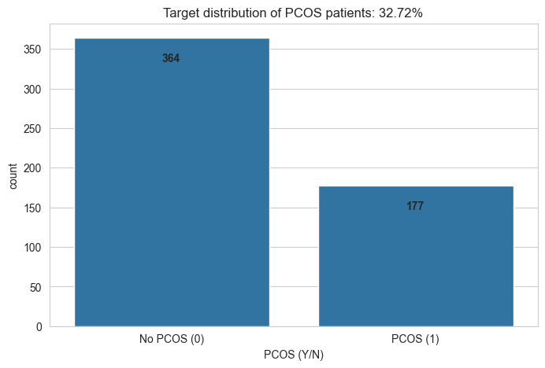

**Komentar**: Vidimo, da je podatkovna baza precej dobro uravnotežena (vsaj bolje kot v primeru predstavljenim na predavanjih; DSWI=4.9% noDSWI=95.1%), zato smo se odločili, da ne bomo dodajali sintetičnih podatkov.

Naslednji koraki:

1. stratificirana razdelitev na učno in testno množico (70% : 30%),
2. predobdelava z OneHotEncoding, skaliranjem in imputacijo manjkajočih vrednosti (median za skalarje in najpogostejša vrednost za kategorične),
3. optimizacija hiperparametrov,
4. primerjava napovedne vrednosti modelov; ne-optimiziranih in optimiziranih.

```
Število primerov v učni množici: 378; število primerov v testni množici: 162
Prediktorji: 41 (31 skalarjev, 10 kategoričnih faktorjev)
Porazdelitev učnih primerov:
```

| PCOS | N | Percent |
| --- | --- | --- |
| 0 | 255 | 67.460317 |
| 1 | 123 | 32.539683 |

```
Porazdelitev testnih primerov:
```

| PCOS | N | Percent |
| --- | --- | --- |
| 0 | 109 | 67.283951 |
| 1 | 53 | 32.716049 |

```
Reusing saved full-search hyperparameters and refitting the ten best pipelines.
```

|  | Model | Accuracy: Default (95% CI) | Accuracy: Tuned (95% CI) | F1: Default (95% CI) | F1: Tuned (95% CI) | ROC_AUC: Default (95% CI) | ROC_AUC: Tuned (95% CI) |
| --- | --- | --- | --- | --- | --- | --- | --- |
| 0 | Random Forest | 0.901 (0.852 to 0.938) | 0.895 (0.846 to 0.938) | 0.837 (0.750 to 0.904) | 0.828 (0.739 to 0.900) | 0.958 (0.922 to 0.984) | 0.950 (0.907 to 0.981) |
| 1 | Gradient Boosting | 0.907 (0.864 to 0.944) | 0.901 (0.858 to 0.944) | 0.845 (0.761 to 0.913) | 0.837 (0.753 to 0.911) | 0.954 (0.916 to 0.981) | 0.954 (0.916 to 0.982) |
| 2 | KNN | 0.858 (0.809 to 0.907) | 0.833 (0.784 to 0.883) | 0.753 (0.652 to 0.842) | 0.682 (0.554 to 0.787) | 0.893 (0.836 to 0.944) | 0.938 (0.890 to 0.972) |
| 3 | XGBoost | 0.907 (0.858 to 0.951) | 0.877 (0.827 to 0.926) | 0.857 (0.781 to 0.923) | 0.815 (0.736 to 0.887) | 0.950 (0.907 to 0.983) | 0.950 (0.910 to 0.980) |
| 4 | LightGBM | 0.895 (0.846 to 0.938) | 0.883 (0.833 to 0.926) | 0.832 (0.747 to 0.904) | 0.822 (0.745 to 0.889) | 0.931 (0.880 to 0.970) | 0.945 (0.903 to 0.978) |
| 5 | AdaBoost | 0.889 (0.840 to 0.932) | 0.883 (0.833 to 0.932) | 0.824 (0.739 to 0.895) | 0.808 (0.716 to 0.889) | 0.940 (0.898 to 0.973) | 0.946 (0.899 to 0.979) |
| 6 | SVC | 0.858 (0.809 to 0.907) | 0.901 (0.858 to 0.944) | 0.777 (0.694 to 0.857) | 0.843 (0.768 to 0.911) | 0.919 (0.865 to 0.963) | 0.943 (0.897 to 0.977) |
| 7 | Logistic Regression | 0.877 (0.827 to 0.920) | 0.907 (0.864 to 0.951) | 0.808 (0.729 to 0.880) | 0.848 (0.769 to 0.918) | 0.929 (0.882 to 0.967) | 0.949 (0.901 to 0.984) |
| 8 | MLP | 0.852 (0.796 to 0.901) | 0.889 (0.840 to 0.932) | 0.769 (0.680 to 0.850) | 0.827 (0.750 to 0.895) | 0.916 (0.868 to 0.959) | 0.947 (0.908 to 0.978) |
| 9 | Decision Tree | 0.858 (0.802 to 0.907) | 0.809 (0.747 to 0.864) | 0.789 (0.707 to 0.865) | 0.705 (0.606 to 0.790) | 0.846 (0.781 to 0.906) | 0.869 (0.806 to 0.921) |

**Komentar**: V tabeli lahko primerjamo sposobnost napovedovanja ne-optimiziranih in optimiziranih modelov. Iz tabele je razvidno, da večina modelov dobro oziroma zelo dobro diskriminira med razredoma ne glede na to, ali je bil model optimiziran ali ne. Če gledamo samo ROC AUC vrednosti, ki podajo splošno diskriminacijsko sposobnost modelov, vidimo, da se pri 7 od 10 modelih ROC AUC vrednost zviša. Največji dvig in sicer za dobre 4 odstotne točke vidimo pri modelu K-NN. Sposobnost diskriminacije pa se z optimizacijo modela ni nujno izboljšala. Modelom GradientBoosting, XGBoost in RandomForest modelu se z optimizacijo parametrov napovedna sposobnost ni spremenila ali pa se je deloma znižala. Vsi modeli so bili testirani na isti testni množici. Za accuracy in F1 smo uporabili klasifikacijski prag 0,50. Za vsako metriko smo izračunali 95% interval zaupanja s stratificiranim bootstrapom, ki je vključeval 2000 ponovitev. Vsi modeli imajo precej visoko ROC AUC oceno, vendar bomo za nadaljno analizo uporabili **RandomForest, GradientBoosting, XGBoost in LOGREG**. LOGREG bo uporabljena kot osnovni model, ki smo ga želeli izboljšati.

|  | Model | Test_accuracy | Test_balanced_accuracy | Test_F1 | Test_ROC_AUC | Test_specificity | Test_sensitivity |
| --- | --- | --- | --- | --- | --- | --- | --- |
| 0 | Random Forest | 0.895 | 0.864 | 0.828 | 0.950 | 0.954 | 0.774 |
| 1 | Gradient Boosting | 0.901 | 0.868 | 0.837 | 0.954 | 0.963 | 0.774 |
| 2 | KNN | 0.833 | 0.760 | 0.682 | 0.938 | 0.972 | 0.547 |
| 3 | XGBoost | 0.877 | 0.865 | 0.815 | 0.950 | 0.899 | 0.830 |
| 4 | LightGBM | 0.883 | 0.869 | 0.822 | 0.945 | 0.908 | 0.830 |
| 5 | AdaBoost | 0.883 | 0.850 | 0.808 | 0.946 | 0.945 | 0.755 |
| 6 | SVC | 0.901 | 0.868 | 0.837 | 0.943 | 0.963 | 0.774 |
| 7 | Logistic Regression | 0.907 | 0.878 | 0.848 | 0.949 | 0.963 | 0.792 |
| 8 | MLP | 0.889 | 0.869 | 0.827 | 0.947 | 0.927 | 0.811 |
| 9 | Decision Tree | 0.809 | 0.780 | 0.705 | 0.869 | 0.862 | 0.698 |

**Komentar**: V tabeli vidimo rezultate metrik modelov na testni množici iz katere je razvidno, da imajo vsi modeli z izjemo DecisionTree in KNN dobro spenzitivnost; število spregledanih pozitivnih primerov je majhno. Najbolje torej bolne paciente zaznavata XGBoost in LightGBM. Najvišjo specifičnost pa imajo K-NN, LOGREG in GradientBoosting. Ti trije modeli pa zaznajo najmanj lažno pozitivnih primerov. Izbira najbolj primernega modela torej zavisi od stroškov zdravljenja in resnosti (smrtnosti) bolezni. Če so stroški zdravljenja veliki, si želimo čim manj lažno pozitivnih pacientk (visoka specifičnost), če pa je bolezen precej smrtonosna želimo čim manj spregledanih pozitivnih (visoka senzitivnost).

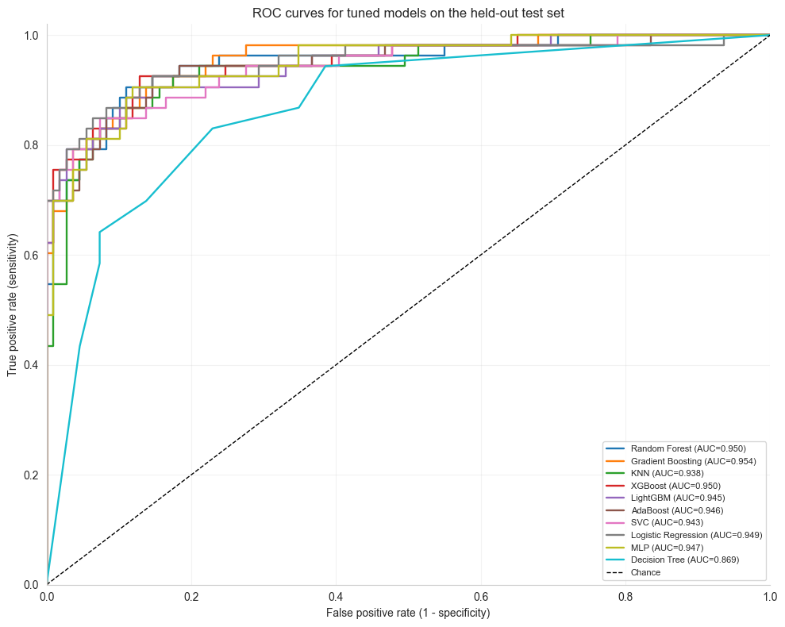

**Komentar**: Na grafu je prikazana ROC AUC krivulja, ki ovrednoti sposobnost modela, da diskriminira med razredoma. Črtkana črta na grafu prikazuje model, ki napoveduje povsem naključno. Cilj grafa je, da ROC-krivulja poteka čim bližje zgornjega levega kota grafa. Iz grafa je razvidno, da vsi razen modela DecisionTree skoraj enako dobro diskriminirajo med razredoma.

V nadaljevanju je ovrednotena statistično značilna razlika med modeli.

```
ROC AUC of tuned models on the held-out test set:
```

|  | Model | ROC AUC (95% CI) |
| --- | --- | --- |
| 0 | Gradient Boosting | 0.954 (0.917 to 0.982) |
| 1 | XGBoost | 0.950 (0.910 to 0.981) |
| 2 | Random Forest | 0.950 (0.907 to 0.982) |
| 3 | Logistic Regression | 0.949 (0.901 to 0.984) |
| 4 | MLP | 0.947 (0.907 to 0.979) |
| 5 | AdaBoost | 0.946 (0.899 to 0.980) |
| 6 | LightGBM | 0.945 (0.903 to 0.979) |
| 7 | SVC | 0.943 (0.896 to 0.979) |
| 8 | KNN | 0.938 (0.891 to 0.975) |
| 9 | Decision Tree | 0.869 (0.808 to 0.924) |

```
Statistically significant ROC AUC differences after Holm correction: 7 of 45 pairs.
```

|  | Model A | Model B | ROC AUC A | ROC AUC B | Difference (95% CI) | Holm-adjusted p | Higher ROC AUC |
| --- | --- | --- | --- | --- | --- | --- | --- |
| 8 | Gradient Boosting | Decision Tree | 0.954 | 0.869 | 0.085 (0.038 to 0.137) | 0.0450 | Gradient Boosting |
| 16 | XGBoost | Decision Tree | 0.950 | 0.869 | 0.081 (0.036 to 0.130) | 0.0450 | XGBoost |
| 23 | Random Forest | Decision Tree | 0.950 | 0.869 | 0.081 (0.033 to 0.133) | 0.0450 | Random Forest |
| 29 | Logistic Regression | Decision Tree | 0.949 | 0.869 | 0.080 (0.030 to 0.132) | 0.0450 | Logistic Regression |
| 34 | MLP | Decision Tree | 0.947 | 0.869 | 0.078 (0.031 to 0.132) | 0.0450 | MLP |
| 41 | LightGBM | Decision Tree | 0.945 | 0.869 | 0.076 (0.032 to 0.126) | 0.0450 | LightGBM |
| 43 | SVC | Decision Tree | 0.943 | 0.869 | 0.074 (0.028 to 0.126) | 0.0450 | SVC |

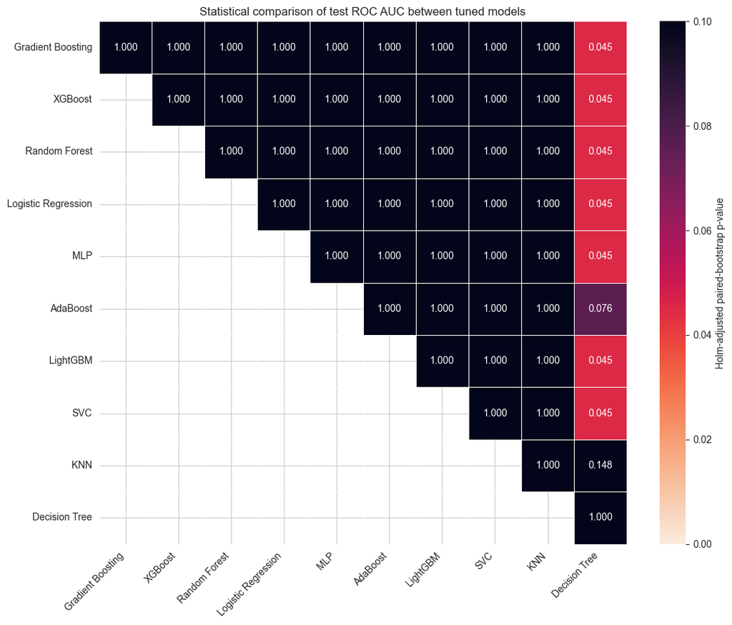

**Komentar**: Iz tabel in grafa je razvidno, da statistično značilnih razlik med modeli ni. Izjema je samo DecisionTree, ki se od vseh modelov, razen od K-NN in AdaBoost modelov statistično značilno razlikuje.

Na modelih RandomForest, Gradien Boosting, LOGREG in XGBoost bomo izvedli še SHAP analizo, ki se uporablja za razlago napovedi modelov strojnega učenja. Pomaga nam razumeti katere značilke najbolj vplivajo na napovedi modela, v katero smer vplivajo in kako močno.

```
Models selected for SHAP analysis: Random Forest, Gradient Boosting, XGBoost, Logistic Regression
[1/4] Calculating permutation SHAP for Random Forest ...
[2/4] Calculating permutation SHAP for Gradient Boosting ...
[3/4] Calculating permutation SHAP for XGBoost ...
[4/4] Calculating permutation SHAP for Logistic Regression ...
```

[output not shown]

[output not shown]

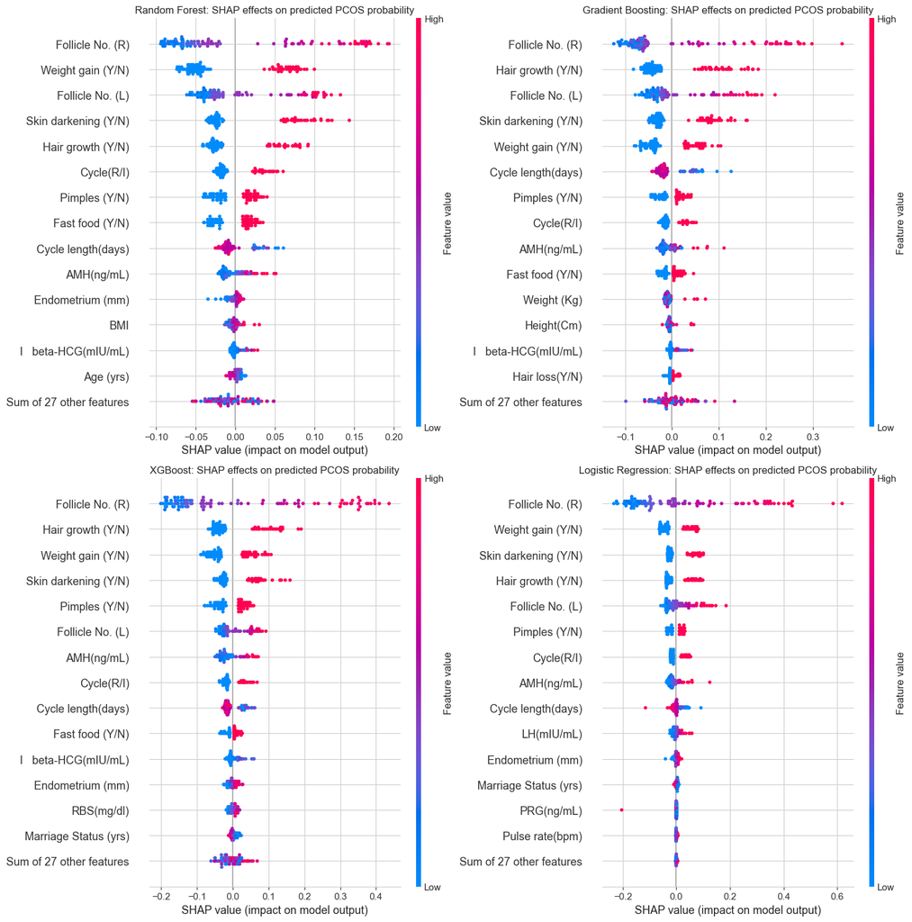

**Komentar**: Iz SHAP-grafov lahko razberemo, kateri kazalniki imajo največji vpliv na napovedi posameznega modela in v katero smer vplivajo nanje. Če primerjamo rezultate vseh štirih modelov, opazimo, da so med najpomembnejšimi kazalniki predvsem Follicle No. (R and L), Weight Gain, Cycle (R/I), Hair Growth, Pimples in Skin Darkening.

Modeli se torej pri svojih napovedih najbolj opirajo na število foliklov v levem in desnem jajčniku ter na nekatere značilne simptome PCOS. Iz grafov je razvidno, da prisotnost mozoljev, povečane poraščenosti, nerednega menstrualnega cikla, povečanja telesne mase in temnenja kože povečuje verjetnost, da bo model posameznico uvrstil v pozitivni razred. Podobno velja tudi za število foliklov, saj večje število foliklov v levem in desnem jajčniku prispeva k napovedi pozitivnega razreda. Čeprav se modeli med seboj nekoliko razlikujejo glede pomembnosti posameznih kazalnikov, se pri klasifikaciji večinoma opirajo na podobne značilke.

V primeru, da bi model uporabljali za presejanje, kjer želimo spregledati čim manj bolnic, imata XGBoost in LightGBM pri pragu 0,50 nekoliko višjo senzitivnost; 0,830 proti 0,792, zato bi lahko uporabili katerega od njiju.